# Reproducible Research: Peer Assessment 1

## Loading and preprocessing the data

Load the data

```r
d <- read.csv("activity.csv")
```

Examine the format of the data

```r
str(d)
```

```
## 'data.frame':    17568 obs. of  3 variables:
##  $ steps   : int  NA NA NA NA NA NA NA NA NA NA ...
##  $ date    : Factor w/ 61 levels "2012-10-01","2012-10-02",..: 1 1 1 1 1 1 1 1 1 1 ...
##  $ interval: int  0 5 10 15 20 25 30 35 40 45 ...
```

```r
head(d)
```

```
##   steps       date interval
## 1    NA 2012-10-01        0
## 2    NA 2012-10-01        5
## 3    NA 2012-10-01       10
## 4    NA 2012-10-01       15
## 5    NA 2012-10-01       20
## 6    NA 2012-10-01       25
```

Change the dates from Factor to Dates

```r
d$date <- as.Date(d$date)
```

Verify change

```
## 'data.frame':    17568 obs. of  3 variables:
##  $ steps   : int  NA NA NA NA NA NA NA NA NA NA ...
##  $ date    : Date, format: "2012-10-01" "2012-10-01" ...
##  $ interval: int  0 5 10 15 20 25 30 35 40 45 ...
```

## What is mean total number of steps taken per day?

**1. Calculate the total number of steps taken per day**

```r
library(dplyr)
steps_df <- d %>%
    group_by(date) %>%
    summarize( tsteps = sum(steps, na.rm=TRUE))
```

**2. If you do not understand the difference between a histogram and a barplot, research the difference between them. Make a histogram of the total number of steps taken each day**

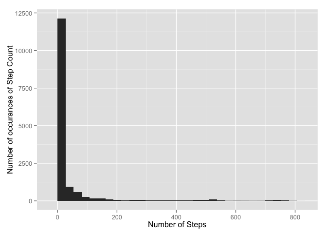

```r
library(ggplot2)
ggplot(data=d, aes(d$steps)) +
    geom_histogram( ) +
    ylab("Number of occurances of Step Count") +
    xlab("Number of Steps")
```

```r
mean_steps = mean(d$steps, na.rm=TRUE)
```

```r
median_steps = median(d$steps, na.rm=TRUE)
```

## What is the average daily activity pattern?

```r
asteps_df <- d %>%
    group_by(interval) %>%
    summarize( asteps = mean(steps, na.rm=TRUE))
```

**1. Make a time series plot (i.e. type = “l”) of the 5-minute interval (x-axis) and the average number of steps taken, averaged across all days (y-axis)**

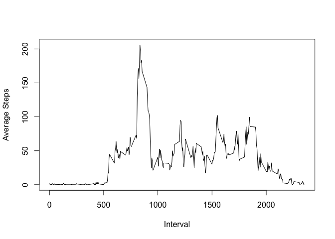

```r
plot( asteps_df$interval, asteps_df$asteps,
      type="n",
      xlab="Interval",
      ylab="Average Steps"
      )
lines(asteps_df$interval, asteps_df$asteps, type="l" )
```

**2.Which 5-minute interval, on average across all the days in the dataset, contains the maximum number of steps?**

```r
m = asteps_df[asteps_df$asteps == max( asteps_df$asteps),]
```

The interval with the most average steps is 835.

## Imputing missing values

**Note that there are a number of days/intervals where there are missing values (coded as NA). The presence of missing days may introduce bias into some calculations or summaries of the data.**

**1. Calculate and report the total number of missing values in the dataset (i.e. the total number of rows with NAs)**

The total number of rows with missing values is 2304.

**2. Devise a strategy for filling in all of the missing values in the dataset. The strategy does not need to be sophisticated. For example, you could use the mean/median for that day, or the mean for that 5-minute interval, etc.**

The strategy to fill in NA values for the number of steps will be to use the rounded mean of the 5-minute interval.

**3. Create a new dataset that is equal to the original dataset but with the missing data filled in.**

```r
nd <- d
#print(nrow(nd))
#head(asteps_df)
for (i in 1:nrow(nd)) {
  if (is.na(nd[i,"steps"])){
    interval <- nd[i,"interval"]
    new_steps <- as.numeric(round(asteps_df[asteps_df[,"interval"]==interval,"asteps"]))
    nd[i,"steps"] <- new_steps
    }
}
#head(nd)
```

```r
library(ggplot2)
sub_plot <- ggplot(data=nd, aes(nd$steps)) +
    geom_histogram( ) +
    ylab("Number of occurances of Step Count") +
    xlab("Number of Steps") +
    ggtitle("Replaced NA Values")
```

The histogram with the substited values.

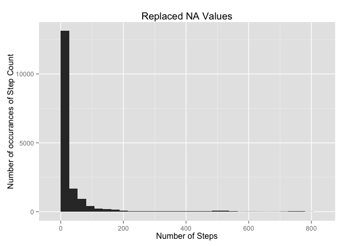

```r
print(sub_plot)
```

```r
sub_mean_steps = mean(nd$steps, na.rm=T)
sub_mean_steps
```

```
## [1] 37.38069
```

```r
sub_median_steps = median(nd$steps)
```

## Are there differences in activity patterns between weekdays and weekends?

**1. Create a new factor variable in the dataset with two levels – “weekday” and “weekend” indicating whether a given date is a weekday or weekend day.**

```r
weekend <- c("Saturday","Sunday")
nd$daytype <- with(nd, ifelse( weekdays(date) %in% weekend, "weekend","weekday"))
```

**2. Make a panel plot containing a time series plot (i.e. type = “l”) of the 5-minute interval (x-axis) and the average number of steps taken, averaged across all weekday days or weekend days (y-axis). See the README file in the GitHub repository to see an example of what this plot should look like using simulated data.**

```r
wday <- subset(nd, daytype=="weekday")
weekday_asteps <- wday %>%
    group_by(interval) %>%
    summarize( asteps = mean(steps, na.rm=TRUE))
head(weekday_asteps)
```

```
## Source: local data frame [6 x 2]
##
##   interval     asteps
## 1        0 2.28888889
## 2        5 0.40000000
## 3       10 0.15555556
## 4       15 0.17777778
## 5       20 0.08888889
## 6       25 1.57777778
```

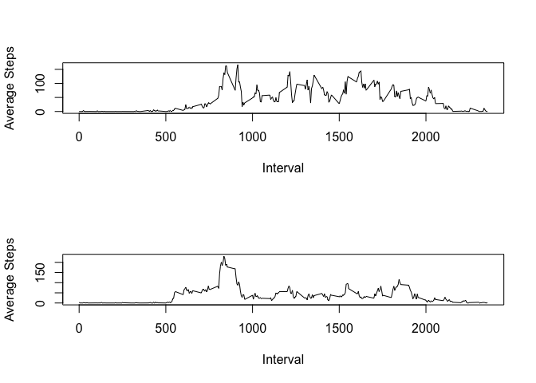

```r
wend <- subset(nd, daytype=="weekend")
weekend_asteps <- wend %>%
    group_by(interval) %>%
    summarize( asteps = mean(steps, na.rm=TRUE))

par(mfrow=c(2,1))
plot( weekend_asteps$interval, weekend_asteps$asteps,
      type="l",
      xlab="Interval",
      ylab="Average Steps"
      )
plot( weekday_asteps$interval, weekday_asteps$asteps,
      type="l",
      xlab="Interval",
      ylab="Average Steps"
      )
```